# Assignment3

Merve Gulsum Kiratli

9/13/2020

This guide explores every element of a diamond and what factors affect diamond prices, positively or negatively. The classical variables of diamond valuation are known as the 4 C’s: Cut, Clarity, Color and Carat weight. But these are just the core, basic factors. There are a multitude of other factors to be taken into consideration when calculating how much a diamond is worth.

How diamond color affects value: even the slightest difference in color has an impact. Simply put, in white diamonds, the less color the better. D is the most valuable color grade on the D-Z scale as it is colorless. Even more valuable than D color are fancy colors: with reds, blues, and green fetching the highest prices.

*CLARITY* When it comes to diamond clarity and how it affects diamond prices, it is quite straightforward. The more clarity characteristics (imperfections) a diamond has, the lower the clarity grade, which in turn lowers the value. Does the diamond look clear to the naked eye or not? It’s a good sign if the diamond does look clear but this does not guarantee that it is a flawless stone. Upon inspection, a gemologist may still be able to spot imperfections. To find out the precise clarity grade of a stone you would need to have a trained gemologist inspect your diamond.

*CUT* When considering how cut grades affect the price of diamonds: excellent cut is optimal. It is worth approximately 15% more than a Very Good (VG) cut grade, which is worth approximately 15% more than a Good (G) cut grade. Only rounds are given cut grades by the GIA. A triple EX grade (i.e. EX cut, EX polish and EX symmetry) is generally worth 7-10% more than a triple VG cut grade.

*SIZE* How to know how much my diamond is worth? Size is a good place to start when answering this question, as the size of a stone is arguably one of the most important factors in pricing a diamond. There are two important points when it comes to diamond size: larger is better and “magic sizes” play a large role.

> Analyzing The Data

First, the necessary packages were loaded and then the data was imported.

```r
library(tidyverse)
```

```r
library(dplyr)
library(dplyr)
library(broom)
library(randomcoloR)
library(rpart)
library(rpart.plot)
library(rattle)
library(cowplot)
library(caret)
```

Train and test data are separated from the data. By looking at the content of the data, it contains information about the carats, cut, color, clarity, depth, table and price of dimonds.

```r
set.seed(503)
diamonds_test<- diamonds %>% mutate(diamond_id=row_number()) %>%
  group_by(cut, color,clarity)%>% sample_frac(0.2)%>% ungroup()

diamonds_train<-anti_join(diamonds %>% mutate(diamond_id=row_number()),
                          diamonds_test, by="diamond_id")
str(diamonds_train)
```

```
## tibble [43,143 x 11] (S3: tbl_df/tbl/data.frame)
##  $ carat     : num [1:43143] 0.21 0.23 0.29 0.31 0.24 0.26 0.22 0.23 0.3 0.23 ...
##  $ cut       : Ord.factor w/ 5 levels "Fair"<"Good"<..: 4 2 4 2 3 3 1 3 2 5 ...
##  $ color     : Ord.factor w/ 7 levels "D"<"E"<"F"<"G"<..: 2 2 6 7 6 5 2 5 7 7 ...
##  $ clarity   : Ord.factor w/ 8 levels "I1"<"SI2"<"SI1"<..: 3 5 4 2 7 3 4 5 3 5 ...
##  $ depth     : num [1:43143] 59.8 56.9 62.4 63.3 62.3 61.9 65.1 59.4 64 62.8 ...
##  $ table     : num [1:43143] 61 65 58 58 57 55 61 61 55 56 ...
##  $ price     : int [1:43143] 326 327 334 335 336 337 337 338 339 340 ...
##  $ x         : num [1:43143] 3.89 4.05 4.2 4.34 3.95 4.07 3.87 4 4.25 3.93 ...
##  $ y         : num [1:43143] 3.84 4.07 4.23 4.35 3.98 4.11 3.78 4.05 4.28 3.9 ...
##  $ z         : num [1:43143] 2.31 2.31 2.63 2.75 2.47 2.53 2.49 2.39 2.73 2.46 ...
##  $ diamond_id: int [1:43143] 2 3 4 5 7 8 9 10 11 12 ...
```

```r
str(diamonds_test)
```

```
## tibble [10,797 x 11] (S3: tbl_df/tbl/data.frame)
##  $ carat     : num [1:10797] 1.7 0.58 1 1.05 0.7 0.9 1.01 1.1 0.62 1.5 ...
##  $ cut       : Ord.factor w/ 5 levels "Fair"<"Good"<..: 1 1 1 1 1 1 1 1 1 1 ...
##  $ color     : Ord.factor w/ 7 levels "D"<"E"<"F"<"G"<..: 1 1 1 1 1 1 1 1 1 1 ...
##  $ clarity   : Ord.factor w/ 8 levels "I1"<"SI2"<"SI1"<..: 1 2 2 2 2 2 2 2 2 2 ...
##  $ depth     : num [1:10797] 64.7 65.1 65.6 65.4 64.5 64.6 64.6 64.6 64.6 68.8 ...
##  $ table     : num [1:10797] 56 58 66 59 60 59 56 54 57 57 ...
##  $ price     : int [1:10797] 5617 1156 3767 3816 2167 3847 3003 4725 1410 7469 ...
##  $ x         : num [1:10797] 7.46 5.25 6.1 6.3 5.53 6.04 6.31 6.56 5.39 6.9 ...
##  $ y         : num [1:10797] 7.37 5.22 6.01 6.24 5.47 6.01 6.24 6.49 5.33 6.86 ...
##  $ z         : num [1:10797] 4.8 3.41 3.97 4.1 3.55 3.89 4.05 4.22 3.46 4.73 ...
##  $ diamond_id: int [1:10797] 13776 40690 5152 5359 49828 5510 1555 10151 43397 18359 ...
```

```r
summary(diamonds)
```

```
##      carat               cut        color        clarity          depth
##  Min.   :0.2000   Fair     : 1610   D: 6775   SI1    :13065   Min.   :43.00
##  1st Qu.:0.4000   Good     : 4906   E: 9797   VS2    :12258   1st Qu.:61.00
##  Median :0.7000   Very Good:12082   F: 9542   SI2    : 9194   Median :61.80
##  Mean   :0.7979   Premium  :13791   G:11292   VS1    : 8171   Mean   :61.75
##  3rd Qu.:1.0400   Ideal    :21551   H: 8304   VVS2   : 5066   3rd Qu.:62.50
##  Max.   :5.0100                     I: 5422   VVS1   : 3655   Max.   :79.00
##                                     J: 2808   (Other): 2531
##      table           price             x                y
##  Min.   :43.00   Min.   :  326   Min.   : 0.000   Min.   : 0.000
##  1st Qu.:56.00   1st Qu.:  950   1st Qu.: 4.710   1st Qu.: 4.720
##  Median :57.00   Median : 2401   Median : 5.700   Median : 5.710
##  Mean   :57.46   Mean   : 3933   Mean   : 5.731   Mean   : 5.735
##  3rd Qu.:59.00   3rd Qu.: 5324   3rd Qu.: 6.540   3rd Qu.: 6.540
##  Max.   :95.00   Max.   :18823   Max.   :10.740   Max.   :58.900
##
##        z
##  Min.   : 0.000
##  1st Qu.: 2.910
##  Median : 3.530
##  Mean   : 3.539
##  3rd Qu.: 4.040
##  Max.   :31.800
##
```

```r
colorsname<-randomColor(8)
colorssname<-randomColor(5)
```

In the first table, the distribution of total diamond according to the cutting types can be seen. At the same time, we can see the color separation within a cut type. As you can see, diamonds with the G-coded color are very popular and at the same time the ones with the ideal type of cut.

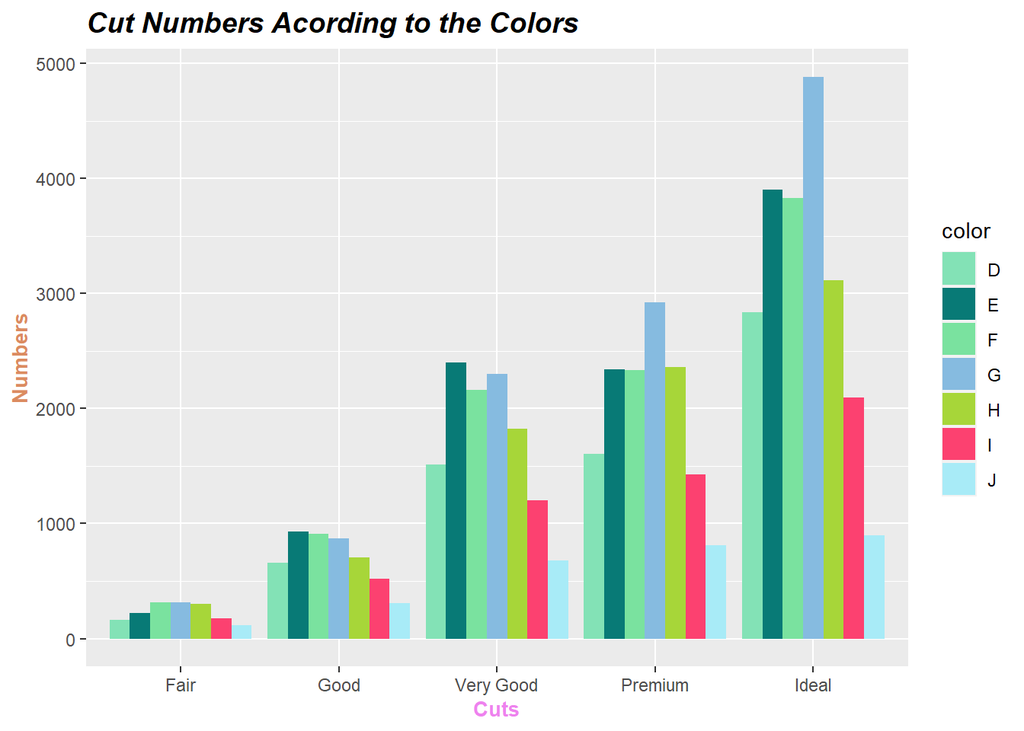

```r
cuts_colors<-ggplot(diamonds)+geom_bar(aes(x = cut, fill = color), position = "dodge")+
  xlab("Cuts") + ylab("Numbers")+
  scale_fill_manual(values =colorsname)+
  theme(plot.title = element_text(color="black", size=14, face="bold.italic"),
        axis.title.x = element_text(color="violet", size=10, face="bold"),
        axis.title.y = element_text(color="#db8b60", size=10, face="bold"))+labs(title = "Cut Numbers Acording to the Colors")
cuts_colors
```

In the second table, the distribution of total diamond according to the cutting types can be seen. At the same time, we can see the clarity separation within a cut type.

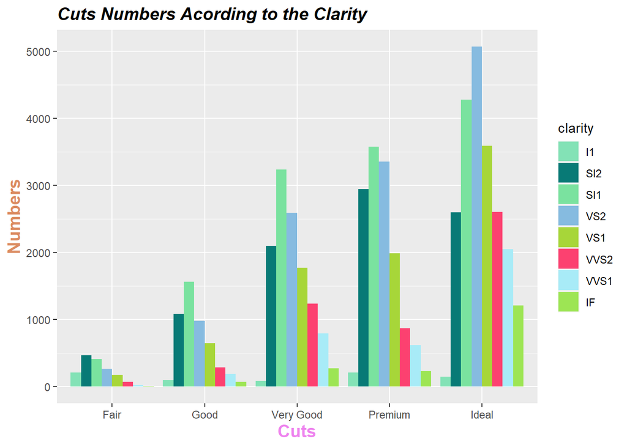

```r
cuts_clarity<-ggplot(diamonds)+geom_bar(aes(x = cut, fill = clarity), position = "dodge")+
  xlab("Cuts") + ylab("Numbers")+
  scale_fill_manual(values =colorsname)+
  theme(plot.title = element_text(color="black", size=14, face="bold.italic"),
        axis.title.x = element_text(color="violet", size=14, face="bold"),
        axis.title.y = element_text(color="#db8b60", size=14, face="bold"))+labs(title = "Cuts Numbers Acording to the Clarity")
cuts_clarity
```

There are barplots drawn according to price and cut style. As can be understood from the graphics, the most expensive diamonds are the Premium ones and the price scale of the Premium diamonds is wider than the others.

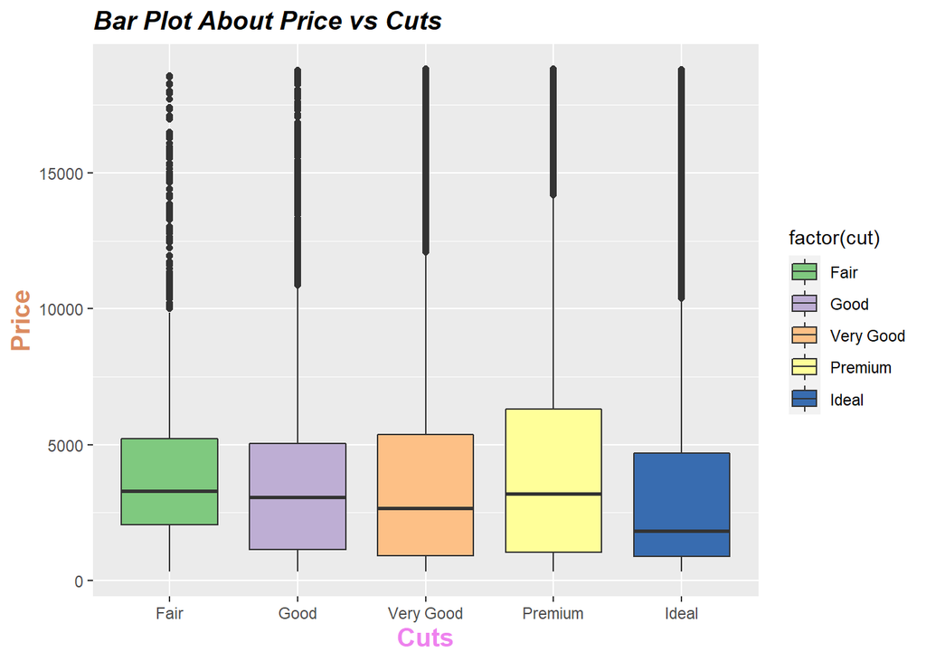

```r
cuts_price<-ggplot(diamonds, aes( cut, price))+
  geom_boxplot(aes(fill=factor(cut)))+
  xlab("Cuts") + ylab("Price")+
  scale_fill_brewer(palette  = "Accent")+
  theme(plot.title = element_text(color="black", size=14, face="bold.italic"),
        axis.title.x = element_text(color="violet", size=14, face="bold"),
        axis.title.y = element_text(color="#db8b60", size=14, face="bold"))+labs(title = "Bar Plot About Price vs Cuts")
     cuts_price
```

```r
diamonds%>% group_by(cut) %>% summarize(Avarage_Price=round(mean(price),2), Count=n())%>%
  mutate(Percentage = 100* round(Count/sum(Count),3))%>%
  arrange(cut)%>%
  select(cut, Count, Percentage, Avarage_Price)
```

```
## # A tibble: 5 x 4
##   cut       Count Percentage Avarage_Price
##   <ord>     <int>      <dbl>         <dbl>
## 1 Fair       1610        3           4359.
## 2 Good       4906        9.1         3929.
## 3 Very Good 12082       22.4         3982.
## 4 Premium   13791       25.6         4584.
## 5 Ideal     21551       40           3458.
```

```r
diamonds%>% group_by(color) %>% summarize(Avarage_Price=round(mean(price),2), Count=n())%>%
  mutate(Percentage = 100* round(Count/sum(Count),3))%>%
  arrange(color)%>%
  select(color, Count, Percentage, Avarage_Price)
```

```
## # A tibble: 7 x 4
##   color Count Percentage Avarage_Price
##   <ord> <int>      <dbl>         <dbl>
## 1 D      6775       12.6         3170.
## 2 E      9797       18.2         3077.
## 3 F      9542       17.7         3725.
## 4 G     11292       20.9         3999.
## 5 H      8304       15.4         4487.
## 6 I      5422       10.1         5092.
## 7 J      2808        5.2         5324.
```

```r
diamonds%>% group_by(clarity) %>% summarize(Avarage_Price=round(mean(price),2), Count=n())%>%
  mutate(Percentage = 100* round(Count/sum(Count),3))%>%
  arrange(clarity)%>%
  select(clarity, Count, Percentage, Avarage_Price)
```

```
## # A tibble: 8 x 4
##   clarity Count Percentage Avarage_Price
##   <ord>   <int>      <dbl>         <dbl>
## 1 I1        741        1.4         3924.
## 2 SI2      9194       17           5063.
## 3 SI1     13065       24.2         3996
## 4 VS2     12258       22.7         3925.
## 5 VS1      8171       15.1         3839.
## 6 VVS2     5066        9.4         3284.
## 7 VVS1     3655        6.8         2523.
## 8 IF       1790        3.3         2865.
```

> Price Estimation

*Multiple linear regression (MLR): also known simply as multiple regression, is a statistical technique that uses several explanatory variables to predict the outcome of a response variable. The goal of multiple linear regression (MLR) is to model the linear relationship between the explanatory (independent) variables and response (dependent) variable.

```r
model_indices<- sample (seq_len(nrow(diamonds)), size = 1*nrow(diamonds), replace = FALSE)
train_indices<- diamonds[model_indices,]
test_indices<- diamonds[-model_indices, ]

log.price<-log(diamonds$price)
LinearModel_1<-lm(log.price~.,data=train_indices)
summary(LinearModel_1)
```

```
##
## Call:
## lm(formula = log.price ~ ., data = train_indices)
##
## Residuals:
##      Min       1Q   Median       3Q      Max
## -2.02443 -0.92859  0.00009  0.79412  2.08850
##
## Coefficients:
##               Estimate Std. Error t value Pr(>|t|)
## (Intercept)  7.810e+00  3.568e-01  21.886   <2e-16 ***
## carat       -3.863e-02  6.166e-02  -0.627    0.531
## cut.L        1.312e-02  2.031e-02   0.646    0.518
## cut.Q       -3.218e-03  1.620e-02  -0.199    0.843
## cut.C        1.143e-02  1.391e-02   0.821    0.411
## cut^4       -1.551e-03  1.111e-02  -0.140    0.889
## color.L      1.702e-02  1.731e-02   0.984    0.325
## color.Q      1.822e-02  1.440e-02   1.265    0.206
## color.C      1.361e-02  1.324e-02   1.028    0.304
## color^4      5.581e-03  1.215e-02   0.460    0.646
## color^5      1.877e-02  1.148e-02   1.635    0.102
## color^6     -1.177e-03  1.043e-02  -0.113    0.910
## clarity.L   -3.269e-03  3.145e-02  -0.104    0.917
## clarity.Q    1.571e-02  2.642e-02   0.595    0.552
## clarity.C   -1.311e-03  2.202e-02  -0.060    0.953
## clarity^4   -1.376e-02  1.737e-02  -0.792    0.428
## clarity^5    4.650e-03  1.417e-02   0.328    0.743
## clarity^6    5.053e-03  1.232e-02   0.410    0.682
## clarity^7    1.539e-02  1.087e-02   1.416    0.157
## depth       -3.542e-05  4.079e-03  -0.009    0.993
## table        1.678e-04  2.616e-03   0.064    0.949
## price        4.660e-06  3.867e-06   1.205    0.228
## x           -1.591e-02  2.980e-02  -0.534    0.593
## y           -7.964e-03  1.736e-02  -0.459    0.646
## z            3.398e-02  3.007e-02   1.130    0.258
## ---
## Signif. codes:  0 '***' 0.001 '**' 0.01 '*' 0.05 '.' 0.1 ' ' 1
##
## Residual standard error: 1.015 on 53915 degrees of freedom
## Multiple R-squared:  0.0002639,  Adjusted R-squared:  -0.0001812
## F-statistic: 0.5929 on 24 and 53915 DF,  p-value: 0.9412
```

```r
LinearModel_2<-lm(log.price~. -cut^3, data=train_indices)
summary(LinearModel_2)
```

```
##
## Call:
## lm(formula = log.price ~ . - cut^3, data = train_indices)
##
## Residuals:
##      Min       1Q   Median       3Q      Max
## -2.01443 -0.92840 -0.00068  0.79471  2.08787
##
## Coefficients:
##               Estimate Std. Error t value Pr(>|t|)
## (Intercept)  7.953e+00  3.119e-01  25.495   <2e-16 ***
## carat       -4.183e-02  6.153e-02  -0.680    0.497
## color.L      1.748e-02  1.728e-02   1.012    0.312
## color.Q      1.862e-02  1.440e-02   1.294    0.196
## color.C      1.348e-02  1.323e-02   1.019    0.308
## color^4      5.385e-03  1.214e-02   0.443    0.657
## color^5      1.867e-02  1.148e-02   1.627    0.104
## color^6     -1.293e-03  1.043e-02  -0.124    0.901
## clarity.L   -1.338e-03  3.138e-02  -0.043    0.966
## clarity.Q    1.517e-02  2.628e-02   0.577    0.564
## clarity.C   -4.973e-04  2.193e-02  -0.023    0.982
## clarity^4   -1.420e-02  1.731e-02  -0.820    0.412
## clarity^5    4.847e-03  1.417e-02   0.342    0.732
## clarity^6    4.999e-03  1.231e-02   0.406    0.685
## clarity^7    1.548e-02  1.087e-02   1.424    0.154
## depth       -9.562e-04  3.793e-03  -0.252    0.801
## table       -1.251e-03  2.121e-03  -0.590    0.555
## price        4.934e-06  3.843e-06   1.284    0.199
## x           -1.648e-02  2.971e-02  -0.555    0.579
## y           -7.356e-03  1.730e-02  -0.425    0.671
## z            3.413e-02  3.004e-02   1.136    0.256
## ---
## Signif. codes:  0 '***' 0.001 '**' 0.01 '*' 0.05 '.' 0.1 ' ' 1
##
## Residual standard error: 1.015 on 53919 degrees of freedom
## Multiple R-squared:  0.0002416,  Adjusted R-squared:  -0.0001293
## F-statistic: 0.6514 on 20 and 53919 DF,  p-value: 0.8761
```

```r
LinearModel_3<-lm(log.price~.-color^3, data=train_indices)
summary(LinearModel_3)
```

```
##
## Call:
## lm(formula = log.price ~ . - color^3, data = train_indices)
##
## Residuals:
##      Min       1Q   Median       3Q      Max
## -2.00669 -0.92899 -0.00043  0.79378  2.08330
##
## Coefficients:
##               Estimate Std. Error t value Pr(>|t|)
## (Intercept)  7.819e+00  3.567e-01  21.918   <2e-16 ***
## carat       -1.383e-02  5.646e-02  -0.245    0.806
## cut.L        1.430e-02  2.027e-02   0.705    0.481
## cut.Q       -4.032e-03  1.619e-02  -0.249    0.803
## cut.C        1.173e-02  1.391e-02   0.843    0.399
## cut^4       -1.509e-03  1.111e-02  -0.136    0.892
## clarity.L    2.984e-03  3.018e-02   0.099    0.921
## clarity.Q    1.109e-02  2.614e-02   0.424    0.671
## clarity.C    6.605e-04  2.193e-02   0.030    0.976
## clarity^4   -1.415e-02  1.736e-02  -0.815    0.415
## clarity^5    4.882e-03  1.416e-02   0.345    0.730
## clarity^6    4.957e-03  1.231e-02   0.403    0.687
## clarity^7    1.538e-02  1.086e-02   1.416    0.157
## depth       -1.406e-04  4.077e-03  -0.034    0.972
## table        1.876e-04  2.616e-03   0.072    0.943
## price        2.965e-06  3.461e-06   0.856    0.392
## x           -1.967e-02  2.965e-02  -0.663    0.507
## y           -7.954e-03  1.736e-02  -0.458    0.647
## z            3.425e-02  3.007e-02   1.139    0.255
## ---
## Signif. codes:  0 '***' 0.001 '**' 0.01 '*' 0.05 '.' 0.1 ' ' 1
##
## Residual standard error: 1.015 on 53921 degrees of freedom
## Multiple R-squared:  0.0001793,  Adjusted R-squared:  -0.0001544
## F-statistic: 0.5373 on 18 and 53921 DF,  p-value: 0.9421
```

```r
LinearModel_4<-lm(log.price ~.-color^3 - cut^3, data=train_indices)
summary(LinearModel_4)
```

```
##
## Call:
## lm(formula = log.price ~ . - color^3 - cut^3, data = train_indices)
##
## Residuals:
##      Min       1Q   Median       3Q      Max
## -2.00624 -0.92895 -0.00127  0.79379  2.07796
##
## Coefficients:
##               Estimate Std. Error t value Pr(>|t|)
## (Intercept)  7.970e+00  3.116e-01  25.576   <2e-16 ***
## carat       -1.634e-02  5.640e-02  -0.290    0.772
## clarity.L    5.259e-03  3.009e-02   0.175    0.861
## clarity.Q    1.024e-02  2.598e-02   0.394    0.693
## clarity.C    1.650e-03  2.184e-02   0.076    0.940
## clarity^4   -1.469e-02  1.730e-02  -0.849    0.396
## clarity^5    5.105e-03  1.416e-02   0.361    0.718
## clarity^6    4.884e-03  1.231e-02   0.397    0.691
## clarity^7    1.546e-02  1.086e-02   1.424    0.155
## depth       -1.146e-03  3.790e-03  -0.302    0.762
## table       -1.272e-03  2.119e-03  -0.600    0.548
## price        3.205e-06  3.445e-06   0.930    0.352
## x           -2.040e-02  2.956e-02  -0.690    0.490
## y           -7.320e-03  1.730e-02  -0.423    0.672
## z            3.440e-02  3.004e-02   1.145    0.252
## ---
## Signif. codes:  0 '***' 0.001 '**' 0.01 '*' 0.05 '.' 0.1 ' ' 1
##
## Residual standard error: 1.015 on 53925 degrees of freedom
## Multiple R-squared:  0.000156,   Adjusted R-squared:  -0.0001036
## F-statistic: 0.6008 on 14 and 53925 DF,  p-value: 0.8668
```

*CART Model: The decision tree method is a powerful and popular predictive machine learning technique that is used for both classification and regression. So, it is also known as Classification and Regression Trees (CART).

Note that the R implementation of the CART algorithm is called RPART (Recursive Partitioning And Regression Trees) available in a package of the same name.

In this chapter we’ll describe the basics of tree models and provide R codes to compute classification and regression trees.

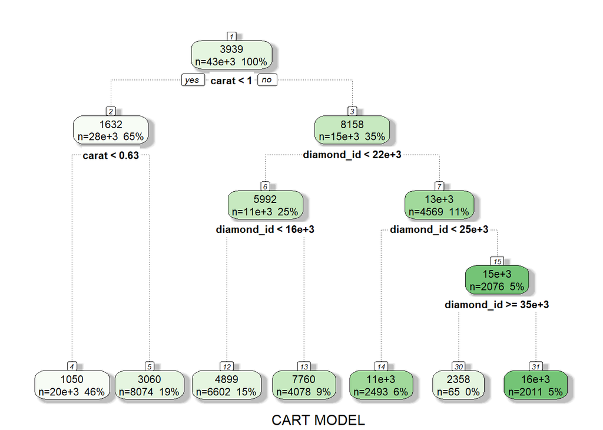

```r
cart_model_train<-rpart(price~., data=diamonds_train)
fancyRpartPlot(cart_model_train, sub="CART MODEL")
```

```r
prediction_model_train<- predict(cart_model_train)
print(head(prediction_model_train))
```

```
##        1        2        3        4        5        6
## 1050.302 1050.302 1050.302 1050.302 1050.302 1050.302
```

```r
prediction_model_train<-as.data.frame(prediction_model_train)
Analysis<-diamonds_train %>% mutate(price, prediction_model_train) %>%
  select(-carat,-cut, -color, -clarity,-depth, -table, -x, -y, -z)
Analysis$error2<-(Analysis$price-Analysis$prediction_model_train)^2
Analysis_error<-Analysis %>% group_by(prediction_model_train) %>%
  summarise(error=min(error2))
#total_error_train=sum(Analyis_error$error)
```

```r
Sq_error<-sum((Analysis$price-Analysis$prediction_model_train)^2)
Sq_total<-sum((Analysis$price-mean(Analysis$price))^2)
Squared<- (Sq_error/Sq_total)
Squared
```

```
## [1] 0.03962667
```